# Espumas de Tajo

Bennett Kohlhepp

2025-06-16

## Conjunto de datos (Final Data)

> Cargar y limpiar datos, formatear fechas Descargar los datos finales

```r
#Descargar los datos
data = read.csv("data_final.csv")

#Quitar el espacio blanco y convertir las fechas al tipo de safont
data_new_fecha = data %>% mutate(Fecha = str_trim(Fecha), Hora = str_trim(Hora), fecha = dmy_hms(paste(Fecha, Hora)))

#Crear datos completos de copernicus
comp_copernicus = data_new_fecha %>% filter(Fuente == "Copernicus")

#Combinar el conjunto de datos con safont
merged_data = left_join(data_new_fecha, safont, by = "fecha")

#Quitar la columna nombre_estacion
merged_data = merged_data %>% select(-nombre_estacion)

#Quitar las filas que no tienen datos
cleaned_na = merged_data %>% filter(!if_all(c(`Temperatura °C`, `pH`, `Conductividad µS/cm`, `Oxígeno mg/l`, `Turbidez NTU`, `Amonio mg/l`, `Fosfatos mg/l`,`Nitratos mg/l`), is.na))

#Convertir los datos al formato safont y quitar los medios
final_data = cleaned_na %>% select(-Fecha, -Hora) %>% filter(Fuente == "Copernicus")

#Cambiar los datos al formatos más bonitos
final_data = final_data %>% rename(Fecha = fecha) %>% select(Fecha, Espuma, Alta_espuma,`Temperatura °C`, `pH`, `Conductividad µS/cm`, `Oxígeno mg/l`, `Turbidez NTU`, `Amonio mg/l`, `Fosfatos mg/l`,`Nitratos mg/l`, Fuente)

#Cambiar el conjunto de datos a inglés
translation_dict = c(
  "Fecha" = "Date",
  "Espuma" = "Foam",
  "Alta_espuma" = "High Foam",
  "Temperatura °C" = "Temperature °C",
  "pH" = "pH",
  "Conductividad µS/cm" = "Conductivity µS/cm",
  "Oxígeno mg/l" = "Oxygen mg/l",
  "Turbidez NTU" = "Turbidity NTU",
  "Amonio mg/l" = "Ammonium mg/l",
  "Fosfatos mg/l" = "Phosphates mg/l",
  "Nitratos mg/l" = "Nitrates mg/l",
  "Fuente" = "Source"
)

final_data = final_data %>%
  mutate(
    Espuma = case_when(
      Espuma == "Sí" ~ "Yes",
      Espuma == "No" ~ "No",
      TRUE ~ NA_character_
    ),
    Alta_espuma = case_when(
      Alta_espuma == "Sí" ~ "Yes",
      Alta_espuma == "No" ~ "No",
      TRUE ~ NA_character_
    )
  )

final_data = final_data %>%
  rename_with(~ translation_dict[.x], .cols = names(translation_dict))

translation_dict2 = c(
  "Fecha" = "Day",
  "Hora" = "Time",
  "Espuma" = "Foam",
  "Alta_espuma" = "High Foam",
  "Fuente" = "Source",
  "fecha" = "Date"
)

comp_copernicus = comp_copernicus %>%
  mutate(
    Espuma = case_when(
      Espuma == "Sí" ~ "Yes",
      Espuma == "No" ~ "No",
      TRUE ~ NA_character_
    ),
    Alta_espuma = case_when(
      Alta_espuma == "Sí" ~ "Yes",
      Alta_espuma == "No" ~ "No",
      TRUE ~ NA_character_
    )
  )

comp_copernicus = comp_copernicus %>%
  rename_with(~ translation_dict2[.x], .cols = names(translation_dict2))
```

> El conjunto de datos “final_data” contiene todos los datos del satélite Copernicus que coinciden por fecha con los datos de Safont. Incluye 178 observaciones. El merge solo incluye los días que tienen al menos una variable fisicoquímica registrada. El conjunto comp_copernicus incluye todos los datos del satélite Copernicus correspondientes a días con y sin presencia de espuma (Sí y No). Incluye 393 observaciones, 198 Sí espuma, 195 No espuma.

## Conjunto de datos (Safont)

> Filtrar datos de Safont desde el año 2016

```r
#Safont de 2016 a 2021
safont_2016 = safont %>% mutate(Year = year(fecha)) %>% filter(Year >= 2016)

#Cambiar el conjunto de datos a inglés
translation_dict_safont = c(
  "nombre_estacion" = "station_name",
  "fecha" = "Date",
  "Temperatura °C" = "Temperature °C",
  "pH" = "pH",
  "Conductividad µS/cm" = "Conductivity µS/cm",
  "Oxígeno mg/l" = "Oxygen mg/l",
  "Turbidez NTU" = "Turbidity NTU",
  "Amonio mg/l" = "Ammonium mg/l",
  "Fosfatos mg/l" = "Phosphates mg/l",
  "Nitratos mg/l" = "Nitrates mg/l"
)

safont_2016 = safont_2016 %>%
  rename_with(~ translation_dict_safont[.x], .cols = names(translation_dict_safont))
```

> El conjunto de datos “safont_2016” incluye todas las observaciones registradas en Safont desde 2016 hasta 2021. Incluye 161.849 observaciones.

## Conjuntos de datos (La temperatura mediana)

> Crear una columna que identifica si la temperatura está por debajo de la mediana (17.3°C).

```r
#Para safont
median_temp_safont = safont_2016 %>% mutate(Below_median = case_when(`Temperature °C` <= 17.3 ~ "Yes", TRUE ~ "No"))
safont_fria = median_temp_safont %>% filter(Below_median == "Yes")
safont_caliente = median_temp_safont %>% filter(Below_median == "No")

#Para data final
median_temp_final = final_data %>% mutate(Below_median = case_when(`Temperature °C` <= 17.3 ~ "Yes", TRUE ~ "No"))
final_fria = median_temp_final %>% filter(Below_median == "Yes")
final_caliente = median_temp_final %>% filter(Below_median == "No")
```

> El conjunto de datos “median_temp_safont” contiene los datos de safont_2016, con una columna adicional que indica si la temperatura está por encima o por debajo de la mediana (17,3°C). Incluye 161.849 observaciones. Además, incluye los subconjuntos “safont_fria” y “safont_caliente”, que contienen únicamente los datos por debajo y por encima de la mediana, respectivamente. Ellos incluyen 78.321 y 83.528 observaciones, respectivamente. El conjunto “median_temp_final” es equivalente a “median_temp_safont”, pero basado en los datos de final_data. Incluye 178 observaciones. Igualmente, final_fria y final_caliente son equivalentes a safont_fria y safont_caliente, pero para los datos de final_data. Ellos incluyen 46 y 132 observaciones, respectivamente.

## Boxplots: Espuma vs No Espuma

> Generar boxplots para comparar los datos de Epsuma SI y NO

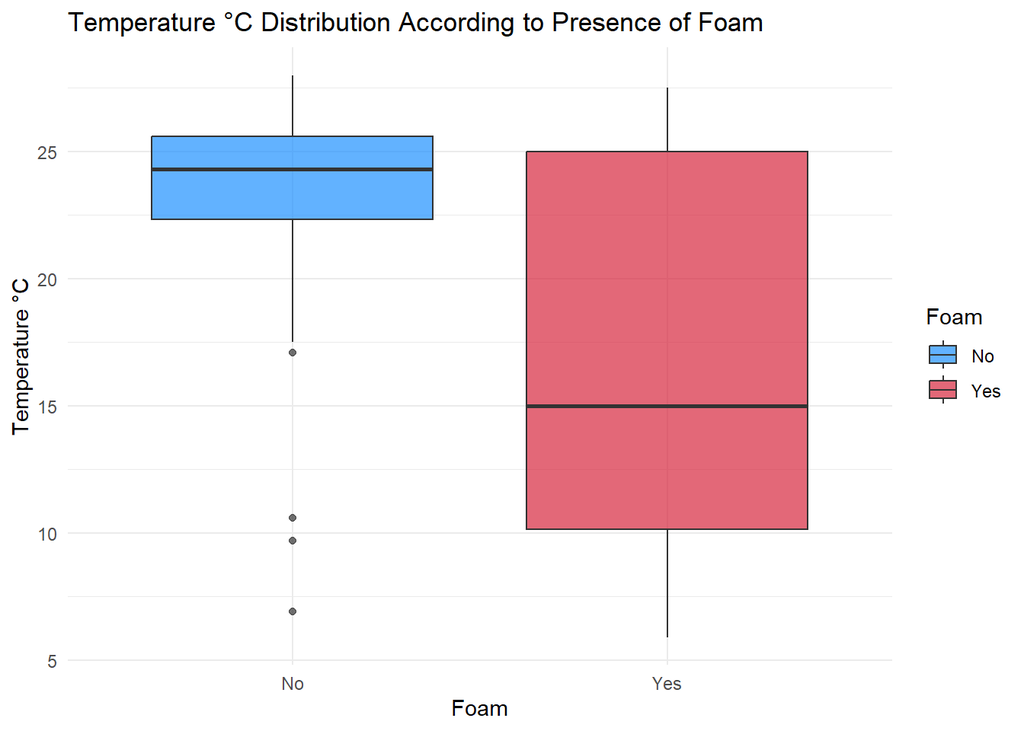

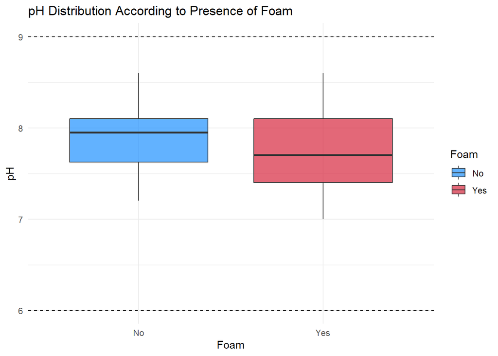

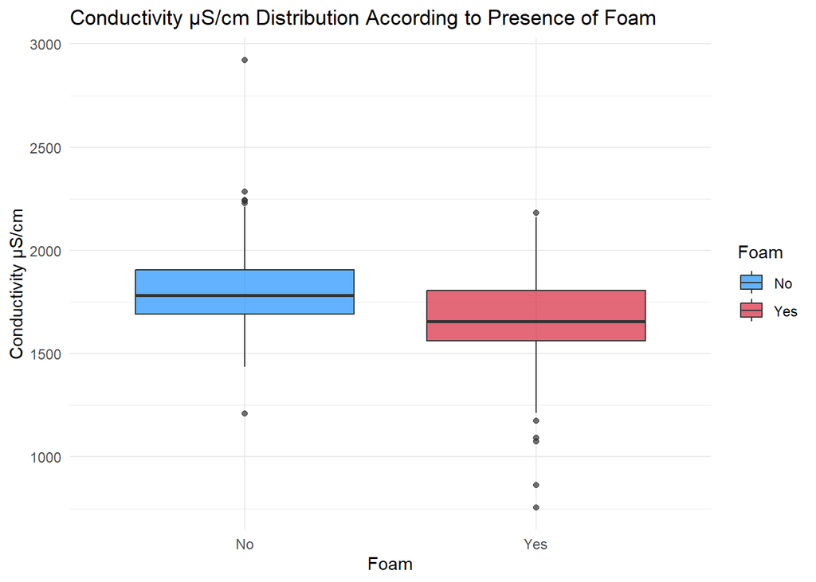

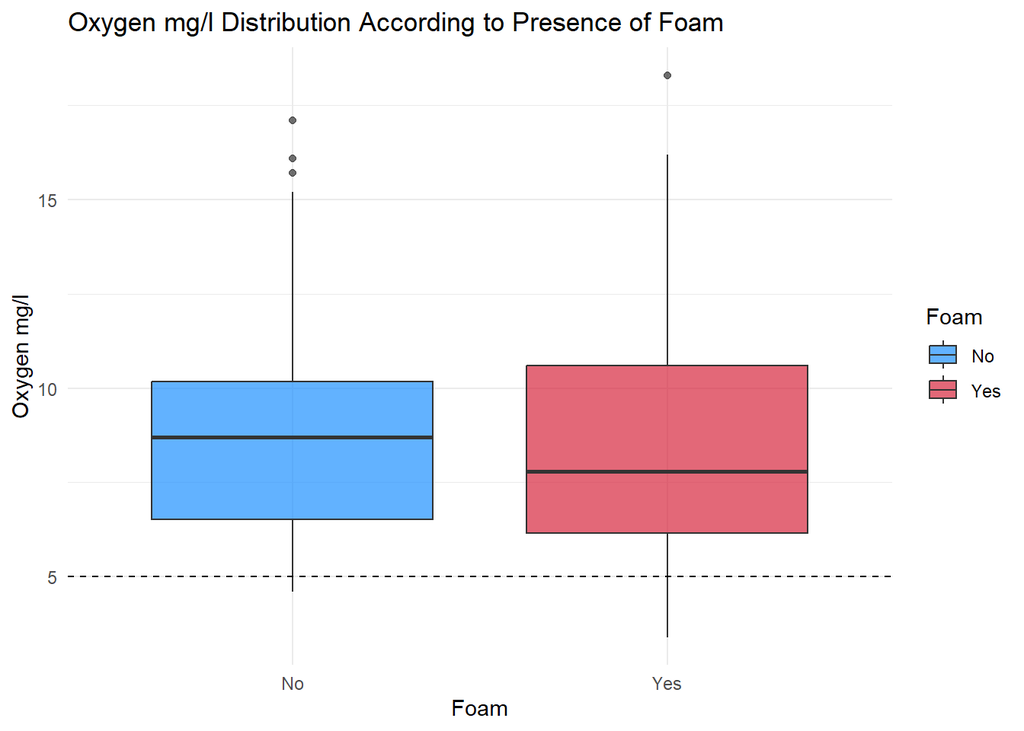

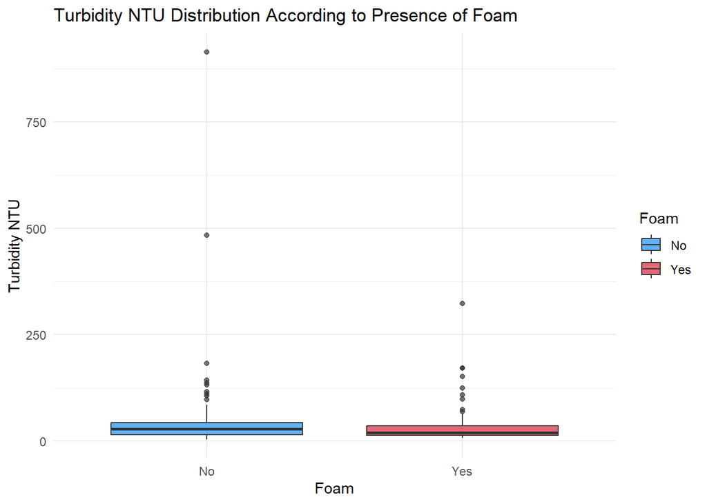

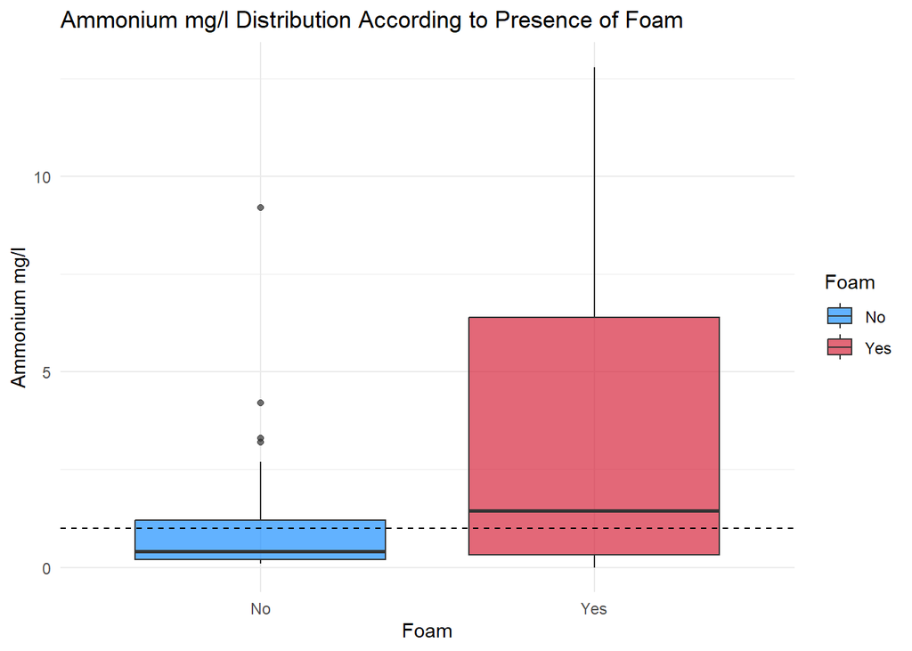

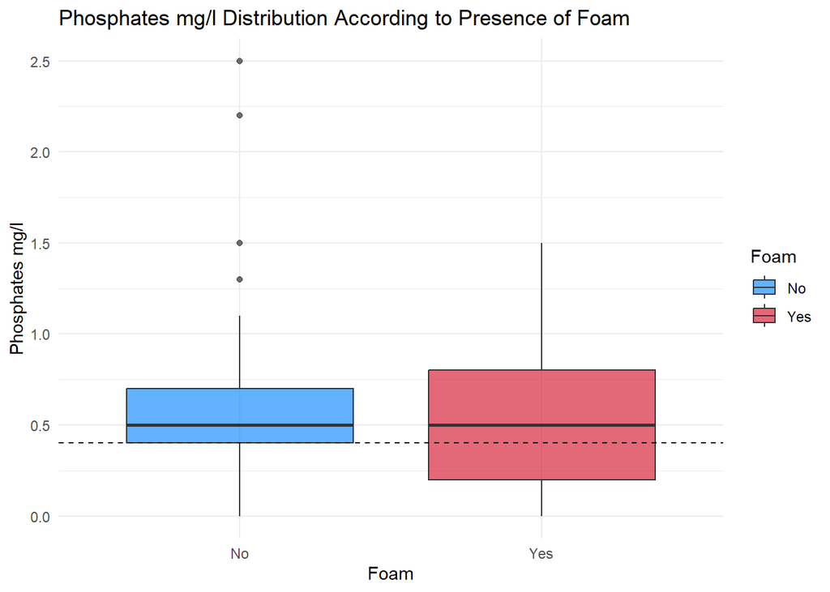

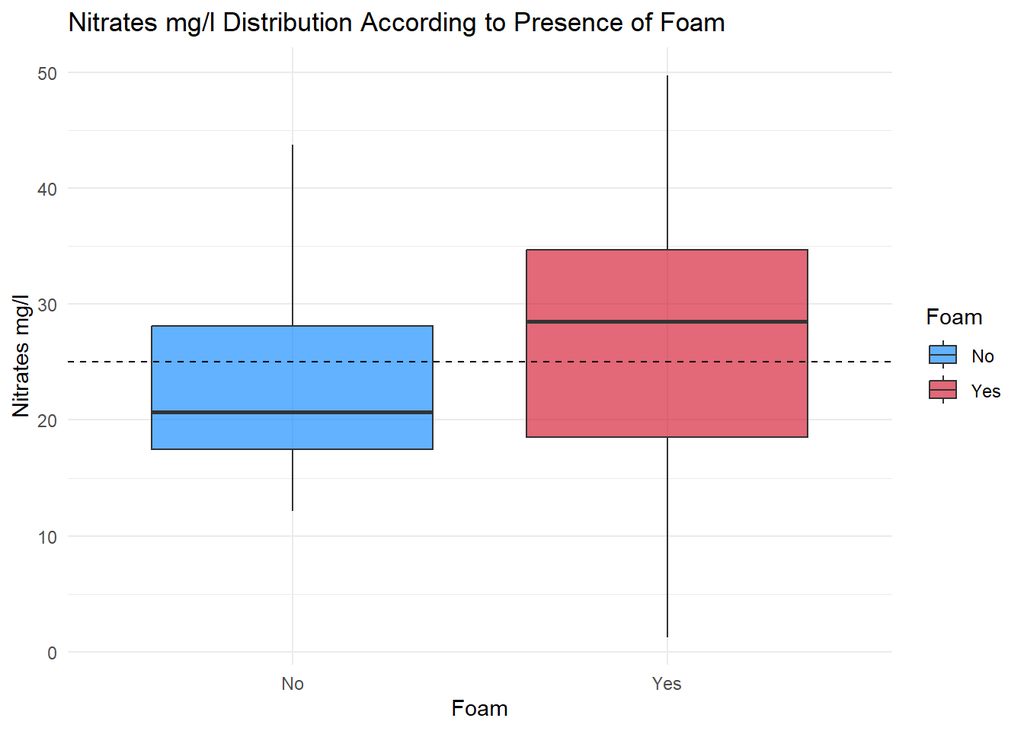

```r
# Todos los factores sin fecha
env_vars = final_data %>%
  select(where(is.numeric), -Date) %>%
  colnames()


# Loop por los factores para generar box-plots
for (var in env_vars) {
  g = ggplot(final_data, aes(x = Foam, y = .data[[var]], fill = Foam)) +
    geom_boxplot(alpha = 0.7) +
    scale_fill_manual(values = c("Yes" = "#D7263D", "No" = "#1E90FF"))+
    labs(title = paste(var, "Distribution According to Presence of Foam"),
         x = "Foam", y = var) +
    theme_minimal()


# Crear los límites
limits = list(
  `pH` = c(6, 9),
  `Oxygen mg/l` = c(5, NA),
  `Ammonium mg/l` = c(NA, 1),
  `Phosphates mg/l` = c(NA, 0.4),
  `Nitrates mg/l` = c(NA, 25)
)


  #Crear los límites de arriba y abajo
  if (!is.null(limits[[var]])) {
    if (!is.na(limits[[var]][1])) {
      g = g + geom_hline(yintercept = limits[[var]][1], linetype = "dashed", color = "black")
    }
    if (!is.na(limits[[var]][2])) {
      g = g + geom_hline(yintercept = limits[[var]][2], linetype = "dashed", color = "black")
    }
  }

  print(g)
}
```

> Estos diagramas de caja comparan la distribución de distintas variables fisicoquímicas del agua entre los días con y sin presencia de espuma, permitiendo identificar diferencias en los valores centrales, la dispersión y la presencia de valores atípicos entre ambos grupos.

> Temperatura: La formación de espuma tiende a estar asociada con temperaturas más bajas, lo que podría indicar un comportamiento estacional o una relación con procesos biológicos o industriales que ocurren con más frecuencia en climas fríos.

> pH: La presencia de espuma se asocia con un pH más ácido. Esto podría estar relacionado con descargas orgánicas o procesos que alteran el equilibrio químico del agua, como la presencia de amonio, quien es un ácido débil, que tiende una presencia más alta en los inviernos.

> Conductividad: La conductividad no muestra una diferencia marcada entre ambos grupos, aunque los días con espuma presentan una mayor dispersión, lo que podría reflejar una variabilidad en los aportes de sales disueltas.

> Oxígeno: El oxígeno tiende a ser ligeramente más bajo en los días con presencia de espuma, y en algunos casos cae por debajo del umbral recomendado (5 mg/l). Sin embargo, esta diferencia podría estar influenciada por otros factores asociados, como la temperatura del agua, que también varía entre ambos grupos. Por lo tanto, no se puede establecer una relación directa entre la presencia de espuma y una disminución del oxígeno sin un análisis más detallado.

> Turbidez: La turbidez presenta una alta variabilidad tanto en días con espuma como sin ella, sin una diferencia sistemática clara entre los grupos. Esto sugiere que la turbidez podría estar influenciada por otros factores independientes de la presencia de espuma.

> Amonio: La presencia de espuma se asocia con altas concentraciones de amonio, lo que puede indicar contaminación orgánica o descargas de aguas residuales.

## Boxplots: Final vs Safont

> Generar boxplots para comparar los datos de espuma SÍ, NO, y Safont Usar colores personalizados y límites de referencia

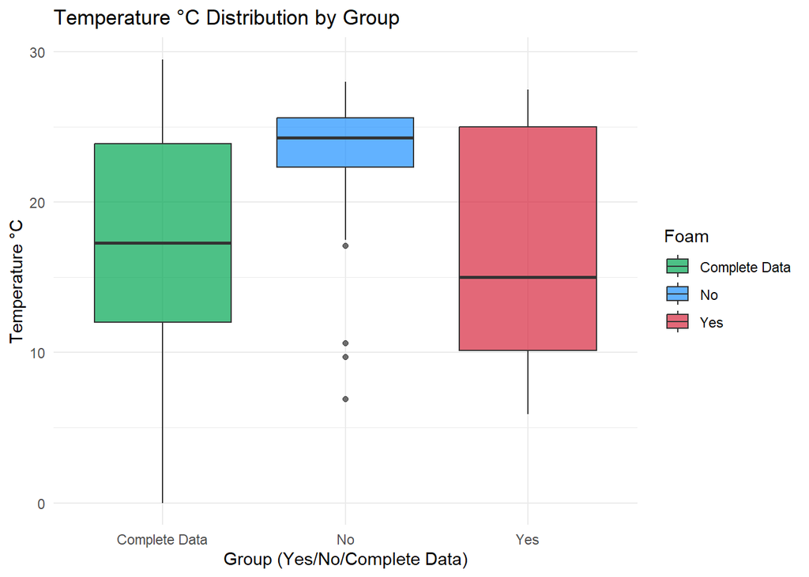

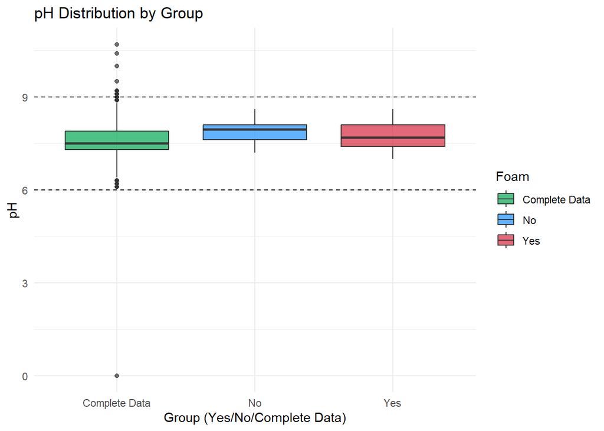

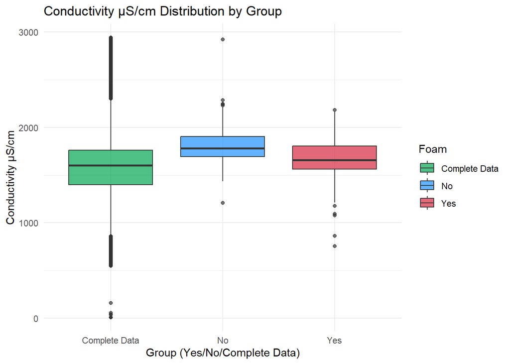

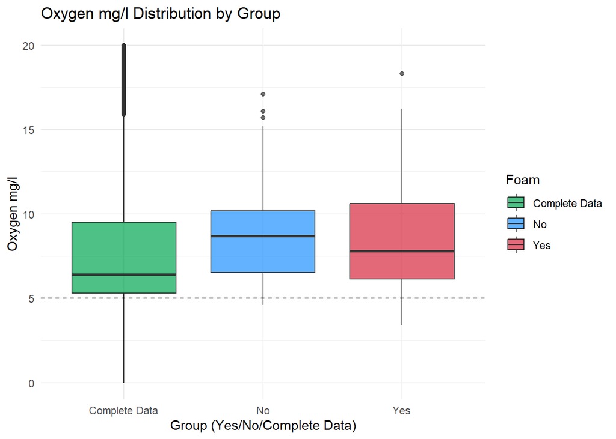

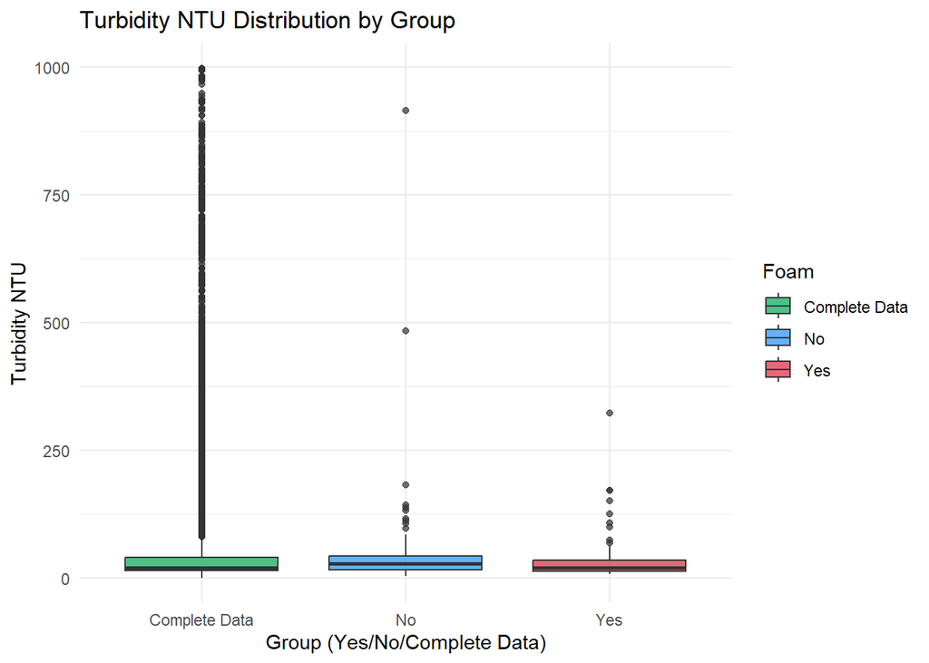

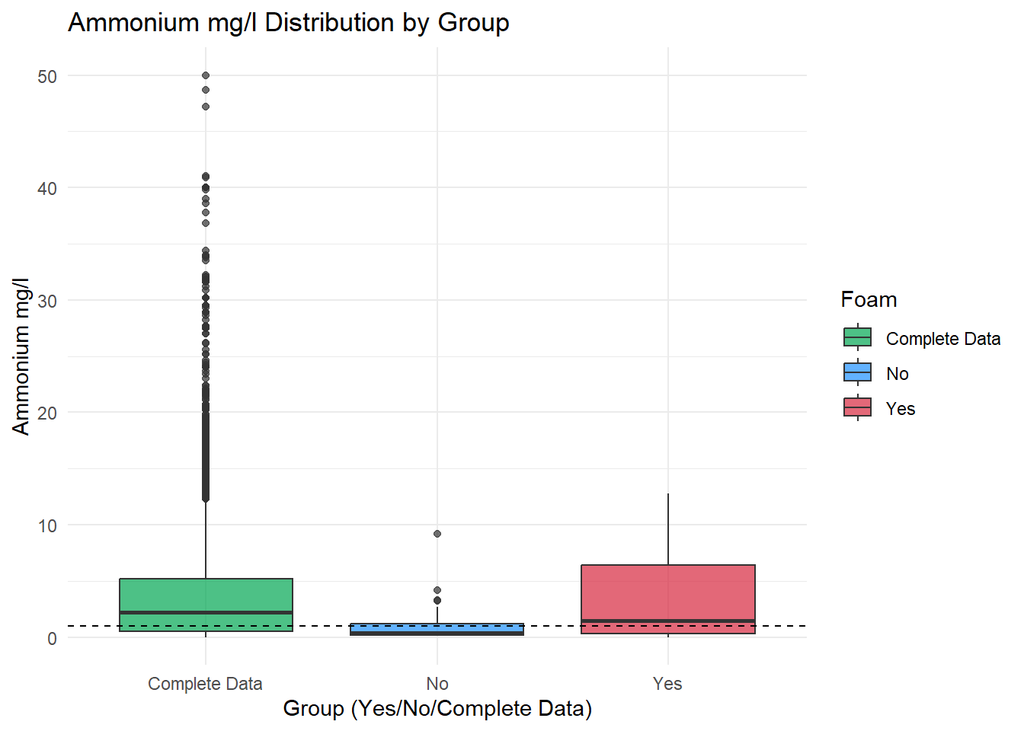

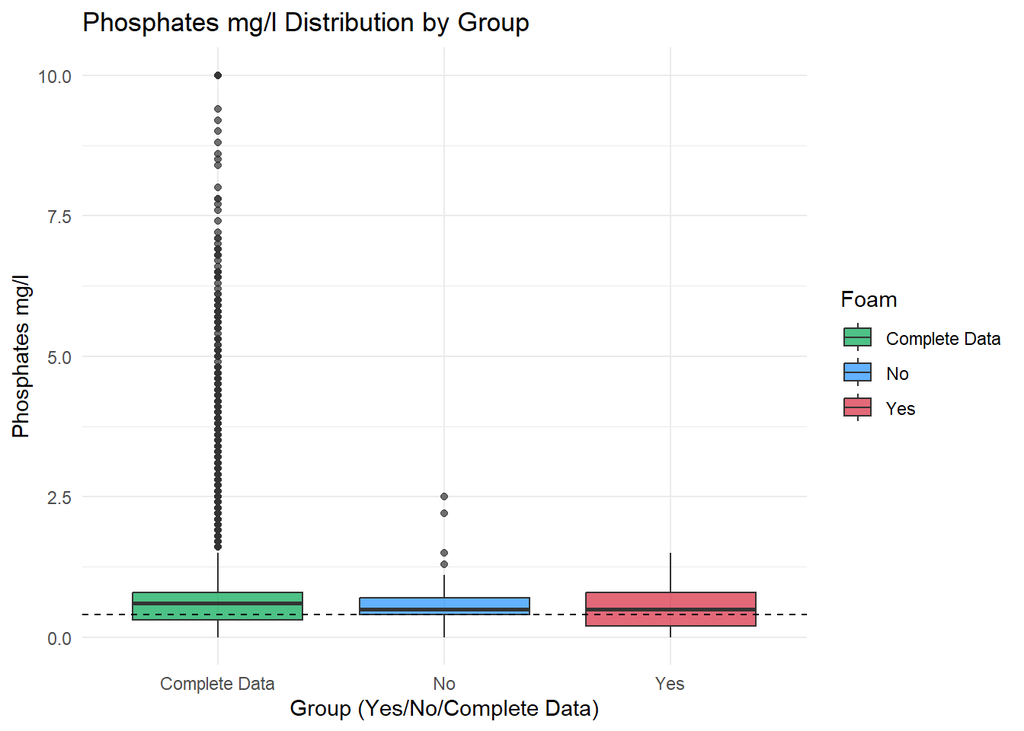

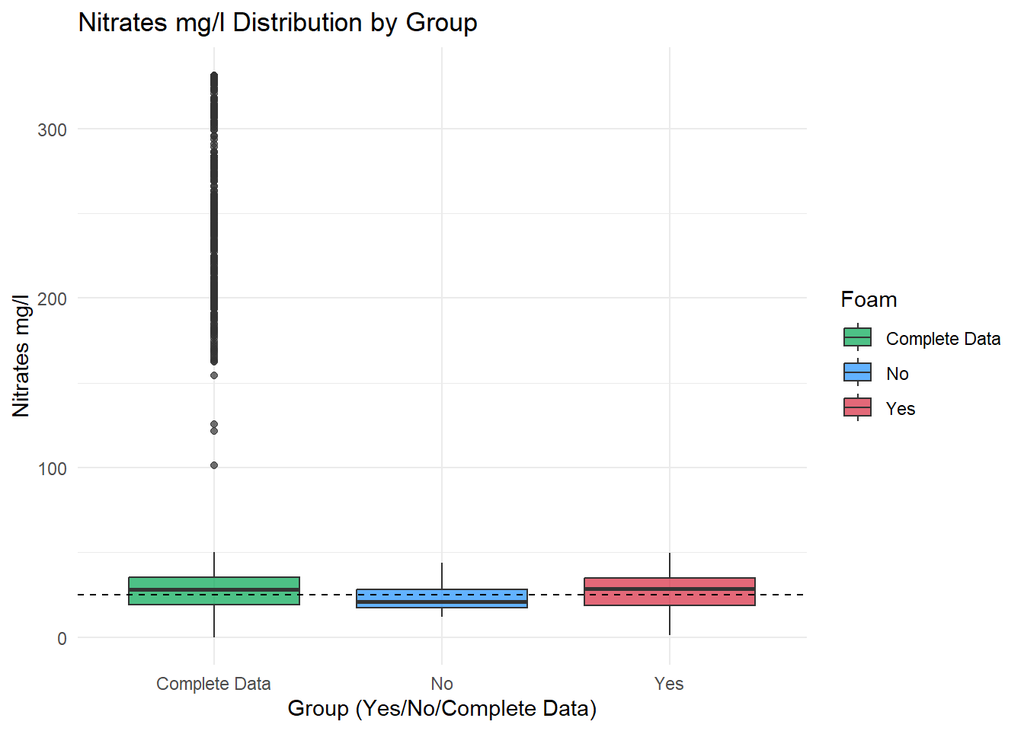

```r
#Variables
env_vars = final_data %>%
  select(where(is.numeric), -Date) %>%
  colnames()

# Limpiar los datos
final_data_labeled = final_data %>%
  filter(Foam %in% c("Yes", "No")) %>%
  select(all_of(env_vars), Foam)


safont_labeled = safont_2016 %>%
  select(any_of(env_vars)) %>%
  mutate(Foam = "Complete Data")

# Combinar los conjuntos de datos
combined_data = bind_rows(final_data_labeled, safont_labeled)

# Boxplots
for (var in env_vars) {
  df = combined_data %>%
    filter(!is.na(.data[[var]]), Foam %in% c("Yes", "No", "Complete Data"))
  if (var == "Nitrates mg/l") {
    combined_data[[var]] = pmin(combined_data[[var]], 100)
  }
  g = ggplot(df, aes(x = Foam, y = .data[[var]], fill = Foam)) +
    geom_boxplot(alpha = 0.7) +
    scale_fill_manual(values = c("Yes" = "#D7263D", "No" = "#1E90FF", "Complete Data" = "#00A651")) +
    labs(title = paste(var, "Distribution by Group"),
         x = "Group (Yes/No/Complete Data)", y = var) +
    theme_minimal()

  if (!is.null(limits[[var]])) {
    if (!is.na(limits[[var]][1])) {
      g = g + geom_hline(yintercept = limits[[var]][1], linetype = "dashed", color = "black")
    }
    if (!is.na(limits[[var]][2])) {
      g = g + geom_hline(yintercept = limits[[var]][2], linetype = "dashed", color = "black")
    }
  }

  print(g)
}
```

## Safont con SÍ o NO espuma destacados

> Unir datos de espuma a Safont y resaltar eventos de espuma con colores

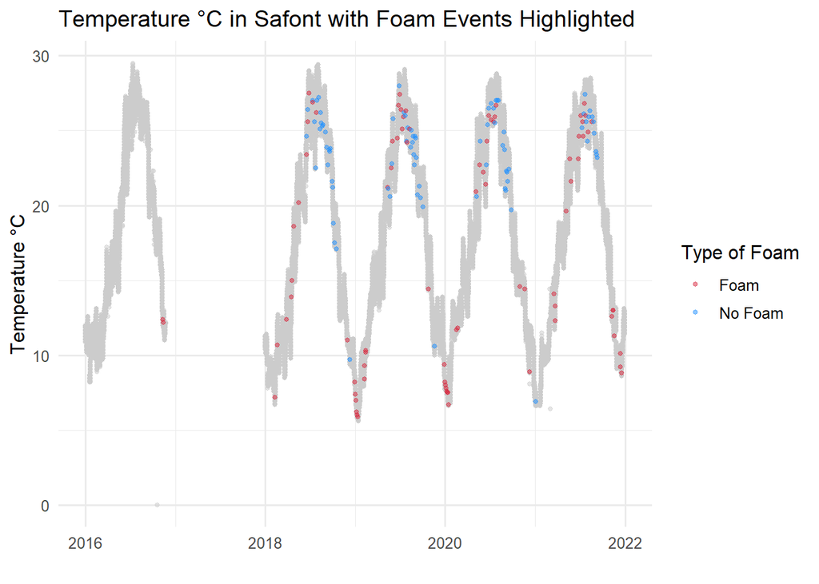

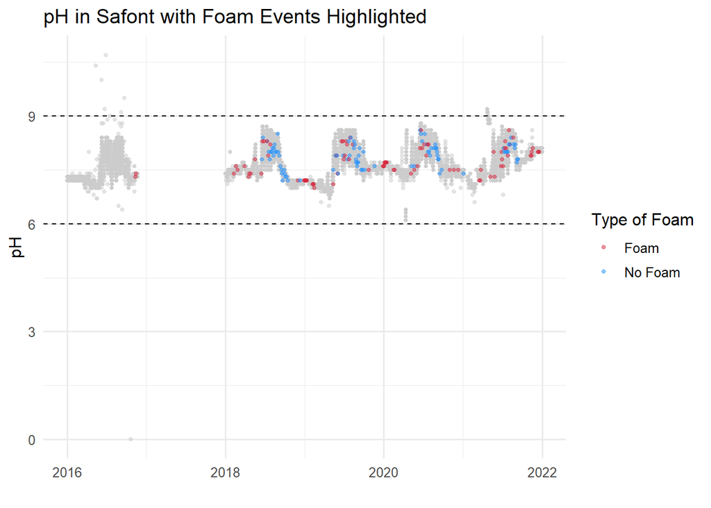

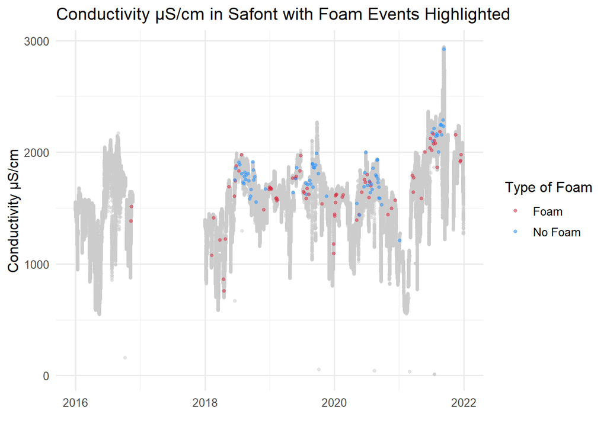

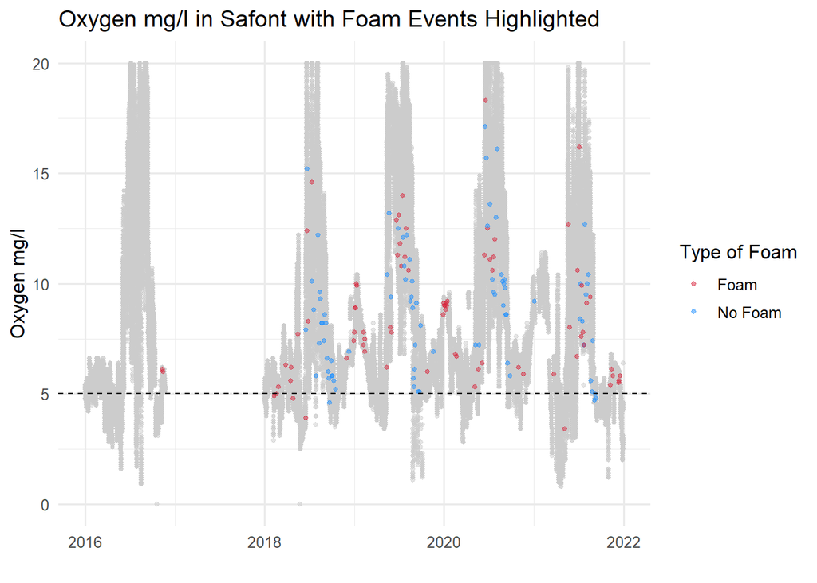

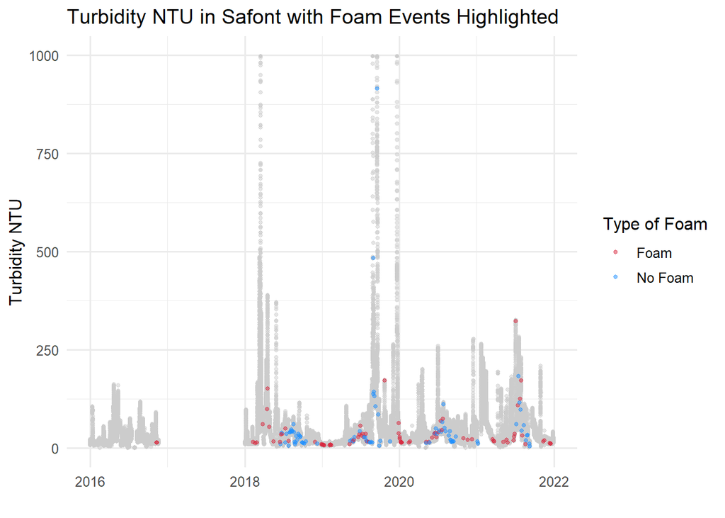

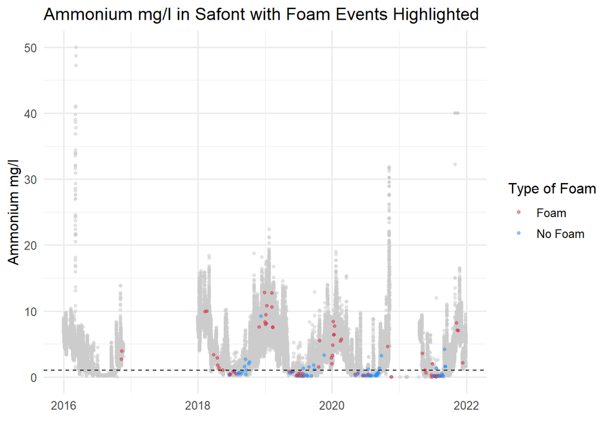

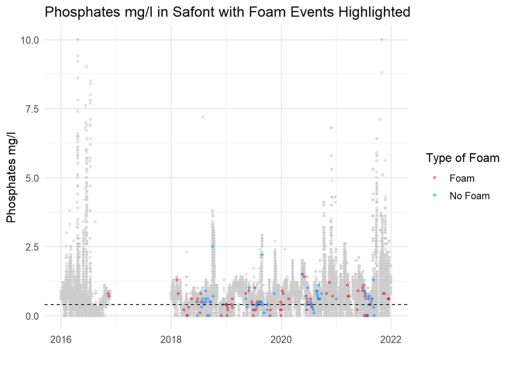

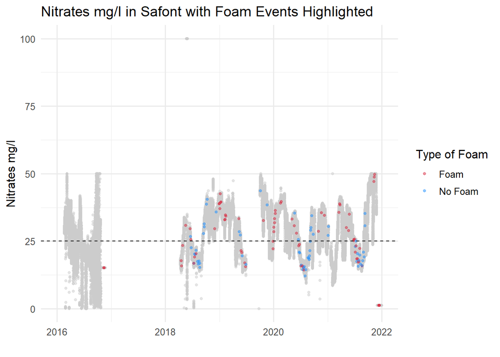

```r
# Combinar safont con data final
safont_highlighted = safont_2016 %>%
  left_join(final_data %>% select(Date, Foam), by = c("Date" = "Date")) %>%
  mutate(Espuma_cat = case_when(
    Foam == "Yes" ~ "Foam",
    Foam == "No" ~ "No Foam",
    TRUE ~ NA_character_
  ))

# Los gráficos
for (var in env_vars) {

  # Límite de nitratos
  if (var == "Nitrates mg/l") {
    safont_highlighted[[var]] = pmin(safont_highlighted[[var]], 100)
  }

  g = ggplot(safont_highlighted, aes(x = Date, y = .data[[var]])) +
    geom_point(data = safont_highlighted %>% filter(is.na(Espuma_cat)),
               color = "gray80", size = 1, alpha = 0.5) +
    geom_point(data = safont_highlighted %>% filter(!is.na(Espuma_cat)),
               aes(color = Espuma_cat), size = 1, alpha = 0.5) +
    scale_color_manual(values = c("Foam" = "#D7263D", "No Foam" = "#1E90FF")) +
    labs(title = paste(var, "in Safont with Foam Events Highlighted"), y = var, x = "", color = "Type of Foam") +
    theme_minimal(base_size = 12)

  if (!is.null(limits[[var]])) {
    if (!is.na(limits[[var]][1])) {
      g = g + geom_hline(yintercept = limits[[var]][1], linetype = "dashed", color = "black")
    }
    if (!is.na(limits[[var]][2])) {
      g = g + geom_hline(yintercept = limits[[var]][2], linetype = "dashed", color = "black")
    }
  }

  print(g)
}
```

## Safont con SI o NO espuma destacados (T <= 17.3°C)

> Unir datos de espuma a Safont fria y resaltar eventos de espuma con colores

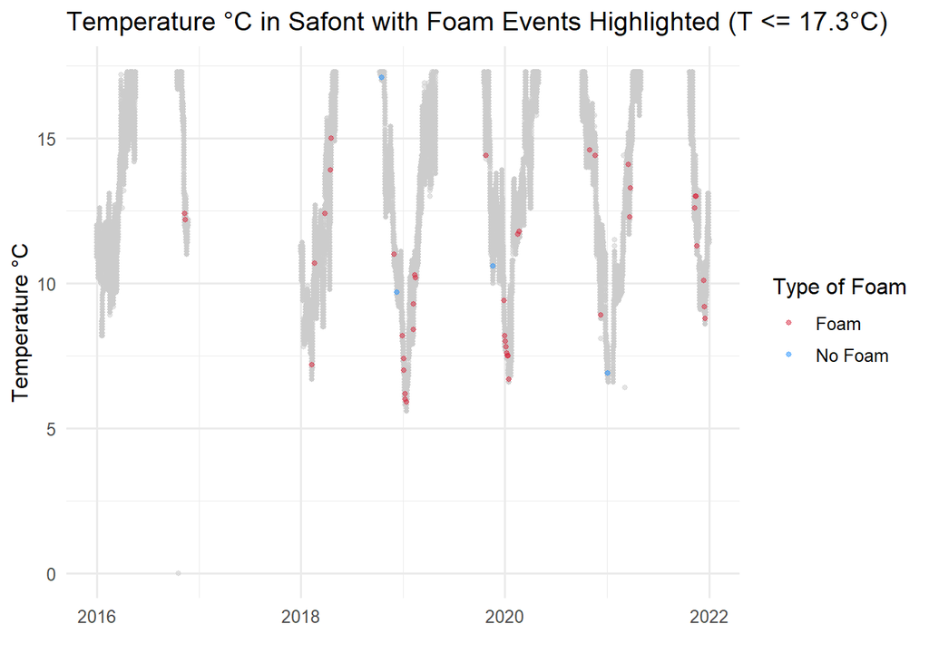

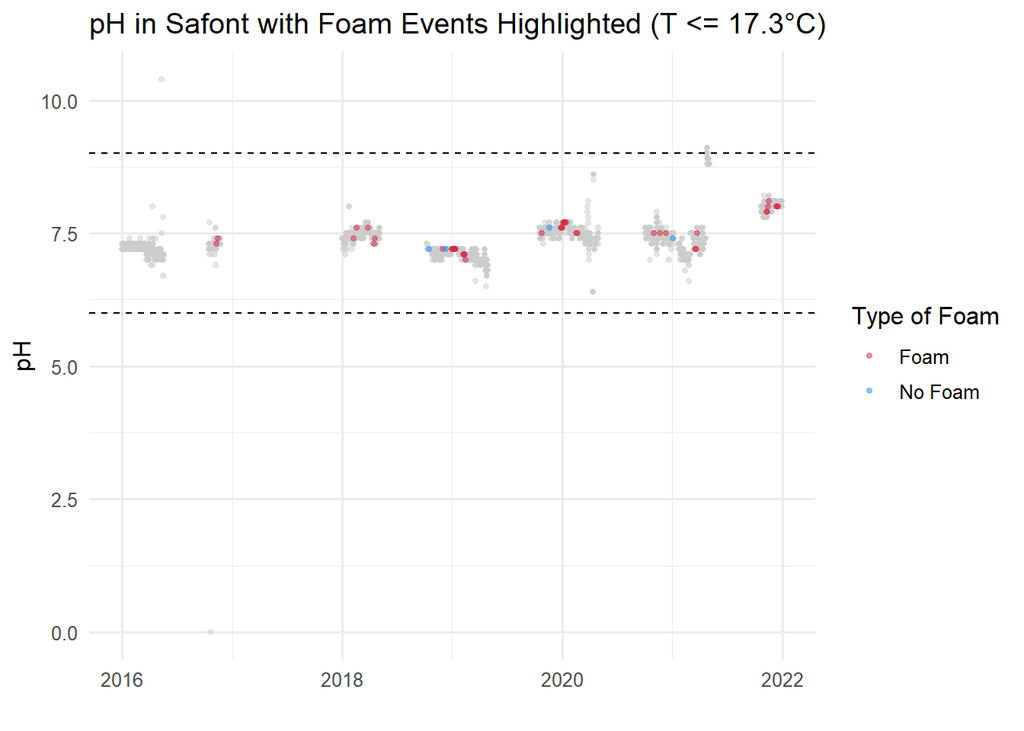

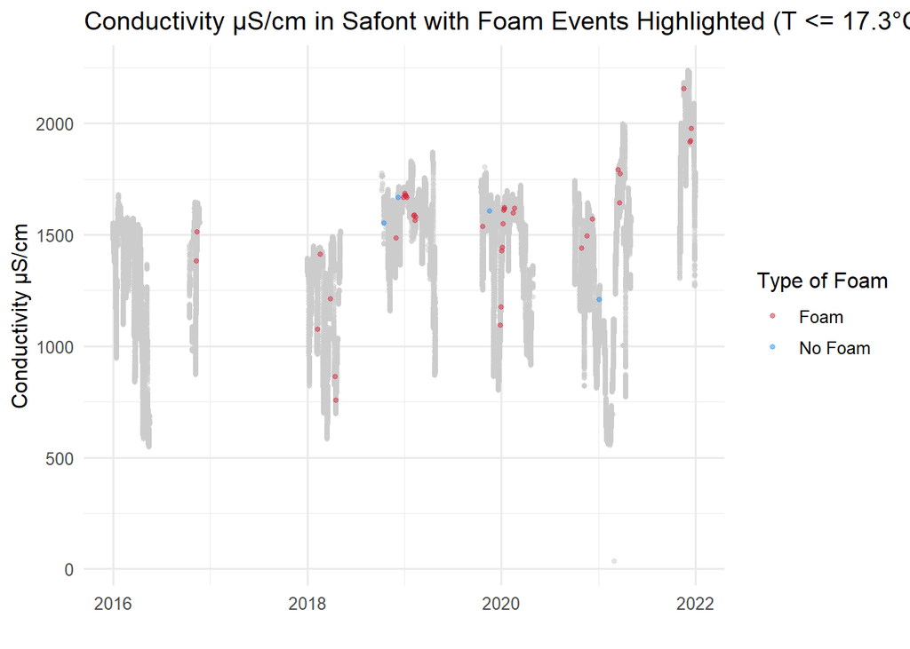

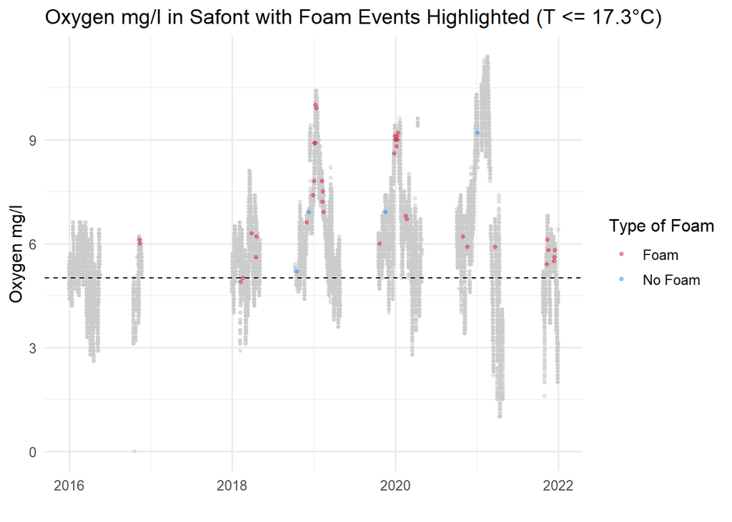

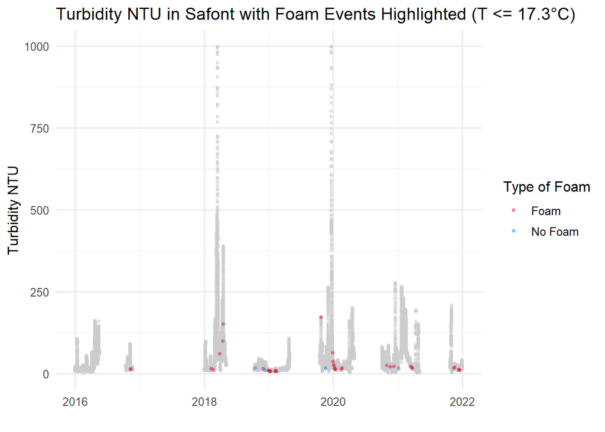

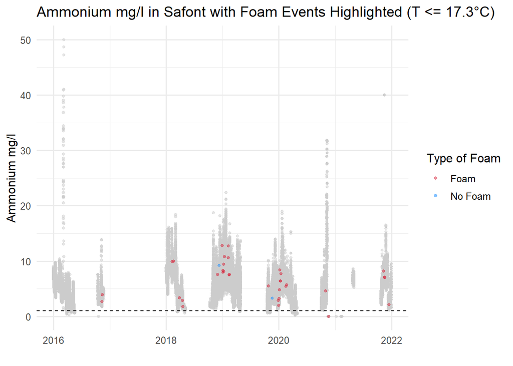

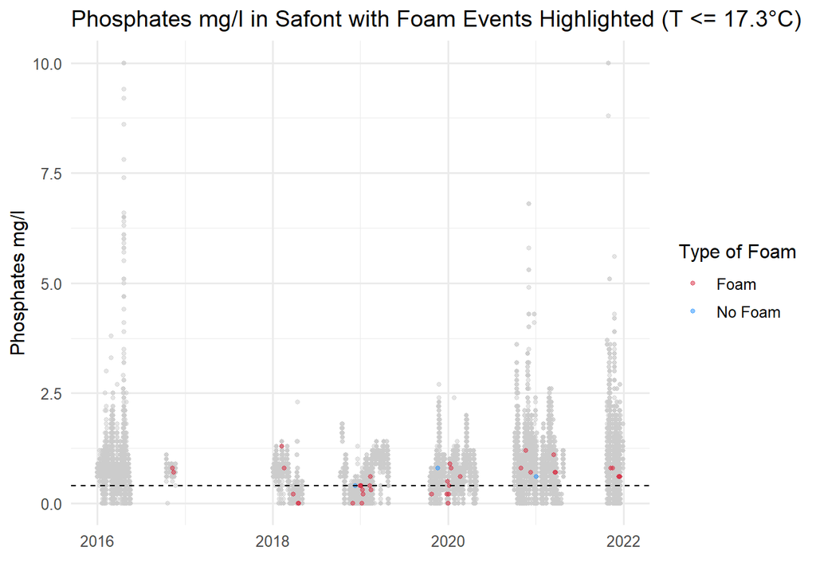

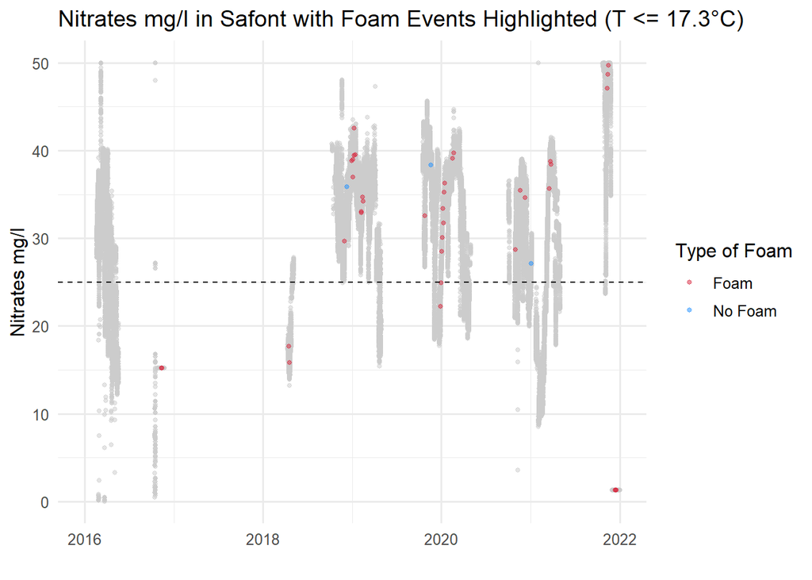

```r
# Combinar safont con data final
safont_highlighted = safont_fria %>%
  left_join(final_fria %>% select(Date, Foam), by = c("Date" = "Date")) %>%
  mutate(Espuma_cat = case_when(
    Foam == "Yes" ~ "Foam",
    Foam == "No" ~ "No Foam",
    TRUE ~ NA_character_
  ))

# Los gráficos
for (var in env_vars) {

  # Límite de nitratos
  if (var == "Nitrates mg/l") {
    safont_highlighted[[var]] = pmin(safont_highlighted[[var]], 100)
  }

  g = ggplot(safont_highlighted, aes(x = Date, y = .data[[var]])) +
    geom_point(data = safont_highlighted %>% filter(is.na(Espuma_cat)),
               color = "gray80", size = 1, alpha = 0.5) +
    geom_point(data = safont_highlighted %>% filter(!is.na(Espuma_cat)),
               aes(color = Espuma_cat), size = 1, alpha = 0.5) +
    scale_color_manual(values = c("Foam" = "#D7263D", "No Foam" = "#1E90FF")) +
    labs(title = paste(var, "in Safont with Foam Events Highlighted (T <= 17.3°C)"), y = var, x = "", color = "Type of Foam") +
    theme_minimal(base_size = 12)

  if (!is.null(limits[[var]])) {
    if (!is.na(limits[[var]][1])) {
      g = g + geom_hline(yintercept = limits[[var]][1], linetype = "dashed", color = "black")
    }
    if (!is.na(limits[[var]][2])) {
      g = g + geom_hline(yintercept = limits[[var]][2], linetype = "dashed", color = "black")
    }
  }

  print(g)
}
```

## Safont con SI o NO espuma destacados (T > 17.3°C)

> Unir datos de espuma a Safont caliente y resaltar eventos de espuma con colores